# A03

Olivia Martin

2022-09-20

**Instructions.** Change the author name on line 4 to be your name. Insert all requested answers. Upload in Moodle this file and a knitted file (html, doc, or pdf).

### Exercise 1 (42 points).

Answer from *Statistical Modeling: End-of-Chapter Exercises* by Daniel Kaplan the following. I provide enough of each problem (Prob) or reading exercise (Read) so that it should be relatively easy to type your answers (text or code) in this file. I also provide some clarifications and hints.

**Read 4.2 (5 points).** How can a difference in group means clearly shown by your data nonetheless be misleading?

Group means can be very misleading when they don’t account for confounding variables. The example given in the text was that, at first glance, smokers seemed to live longer, but the smokers were also younger on average than non-smokers when the study began. Another example I heard (possibly from you) is that people from countries where cell phones are common tend to live much longer than people from other countries. But cell phones don’t actually make people live longer; cell phones tend to be most prevalent in more developed countries with advanced and widely available medical care. (I say tend to because America is obviously a huge outlier in availability.)

**Read 4.3 (5 points).** What does it mean to partition variation? What’s special about the variance — the square of the standard deviation — as a way to measure variation?

The variance is special because it’s able to partition variation— that is, it can tell you how much variation the model accounts for, and how much is still unexplained. This does not mean that your model explains the cause of the variation. After all, correlation isn’t causation.

**Prob 4.05 (a) and (c) (20 points).** Create a tibble with the state data including a fourth column named `dist` for which you choose appropriate numbers to answer part (c). You only need to include the appropriate calculations to show the answers to the given questions.

```r
football = tibble(distance = c(5,12,11,2,18,12,15,19,5,12), team = c('Eagles','Eagles','Eagles','Doves','Doves','Penguins','Penguins','Eagles','Penguins','Penguins'), position = c('center','forward','end','center','end','forward','end','back','center','back'), dist = c(13,13,15,14,16,12,12,15,14,14))

mean(football$distance)
```

```
## [1] 11.1
```

```r
football %>% group_by(team) %>% summarise(mean = mean(distance))
```

```
## # A tibble: 3 × 2
##   team      mean
##   <chr>    <dbl>
## 1 Doves     10
## 2 Eagles    11.8
## 3 Penguins  11
```

```r
football %>% group_by(position) %>% summarise(mean = mean(distance))
```

```
## # A tibble: 4 × 2
##   position  mean
##   <chr>    <dbl>
## 1 back      15.5
## 2 center     4
## 3 end       14.7
## 4 forward   12
```

```r
football %>% group_by(team) %>% summarise(mean = mean(dist))
```

```
## # A tibble: 3 × 2
##   team      mean
##   <chr>    <dbl>
## 1 Doves       15
## 2 Eagles      14
## 3 Penguins    13
```

**Prob 4.06 (12 points).** Do not use the `fetchData` command; the desired data is in `CPS85`. You need only to include an appropriate code chunk calculation that yields the desired answer. The `filter` command is better than `group_by` to answer these questions.

1. What is the grand mean of wage?

   ```r
   mean(CPS85$wage)
   ```

   ```
   ## [1] 9.024064
   ```

2. What is the group-wise mean of wage for females?

   ```r
   filter(CPS85, sex == 'F') %>% summarise(mean = mean(wage))
   ```

   ```
   ##       mean
   ## 1 7.878857
   ```

3. What is the group-wise mean of wage for married people?

   ```r
   filter(CPS85, married == 'Married') %>% summarise(mean = mean(wage))
   ```

   ```
   ##       mean
   ## 1 9.398486
   ```

4. What is the group-wise mean of wage for married females?

   ```r
   filter(CPS85, sex == 'F', married == 'Married') %>% summarise(mean = mean(wage))
   ```

   ```
   ##       mean
   ## 1 7.683765
   ```

### Exercise 2 (30 points).

Consider the `height` variable of the `Galton` data set. Further consider two models for `height`:  
- model0 uses a single number, and  
- model1 uses a number for each value of `sex`.  
Residuals for a model are the differences between the data and the model. Variation can be measured in a variety of ways. Each part states what statistic to use for the model and how to measure variation. Calculate model0 values, residuals for model0, model1 values, and residuals for model1,. Then calculate the variations of the data, model values, and residuals. Does the variation of the data equal the sum of the model and residual variations for model0? If so, compute the percentage of the data variation that is accounted for by model0. Does the variation of the data equal the sum of the model and residual variations for model1? If so, compute the percentage of the data variation that is accounted for by model1.

1. Use the mean for the models and the variance to measure variation.

   ```r
   df = Galton %>%
     select(sex, height) %>%
     mutate(sex = sex,
            mod0 = mean(height),
            res0 = mod0 - height)

   model1 = df %>%
     group_by(sex) %>%
     summarise(mod1 = mean(height))

   df = df %>%
     left_join(model1, 'sex') %>%
     mutate(res1 = mod1 - height)

   df %>% summarise(var(height), var(mod0), var(res0), var(mod1), var(res1), sum = var(mod1)+var(res1), exp0 = var(mod0)/var(height), exp1 = var(mod1)/var(height))
   ```

   ```
   ##   var(height) var(mod0) var(res0) var(mod1) var(res1)     sum exp0      exp1
   ## 1     12.8373         0   12.8373  6.549134  6.288171 12.8373    0 0.5101643
   ```

   var(height) = var(mod0) + var(res0), so we can conclude that model0 explains 0% of the variation. var(height) = var(mod1) + var(res1), so we can conclude that model1 explains 51% of the data.
2. Use the median for the models and the average absolute deviation from the median to measure variation.

   ```r
   df = Galton %>%
     select(sex, height) %>%
     mutate(sex = sex,
            mod0 = median(height),
            res0 = mod0 - height)

   model1 = df %>%
     group_by(sex) %>%
     summarise(mod1 = median(height))

   df = df %>%
     left_join(model1, 'sex') %>%
     mutate(res1 = mod1 - height)

   ad = function(data) {
     mean(abs(data - median(data)))
   }

   df %>% summarise(ad(height), ad(mod0), ad(res0), ad(mod1), ad(res1), sum = ad(mod1)+ad(res1), exp0 = ad(mod0)/ad(height))
   ```

   ```
   ##   ad(height) ad(mod0) ad(res0) ad(mod1) ad(res1)      sum exp0
   ## 1   2.981403        0 2.981403  2.50735  1.99833 4.505679    0
   ```

   As before, ad(height) = ad(mod0) + ad(res0), so model0 explains 0% of the variation. However, sum $\neq$ ad(height), so we cannot conclude anything about the percentage of the variation that model1 explains.
3. Use the median for the models and the interquartile range to measure variation.

   ```r
   df = Galton %>%
     select(sex, height) %>%
     mutate(sex = sex,
            mod0 = median(height),
            res0 = mod0 - height)

   model1 = df %>%
     group_by(sex) %>%
     summarise(mod1 = median(height))

   df = df %>%
     left_join(model1, 'sex') %>%
     mutate(res1 = mod1 - height)

   df %>% summarise(iqr(height), iqr(mod0), iqr(res0), iqr(mod1), iqr(res1), sum = iqr(mod1)+iqr(res1), exp0 = iqr(mod0)/iqr(height))
   ```

   ```
   ##   iqr(height) iqr(mod0) iqr(res0) iqr(mod1) iqr(res1) sum exp0
   ## 1         5.7         0       5.7       5.2       3.3 8.5    0
   ```

   As before, model0 explains 0% of the variation, but sum $\neq$ iqr(height), so we cannot conclude anything about the percentage of the variation that model1 explains.

### Exercise 3 (60 points)

Complete an analysis of the M&Ms data collected by the class with the following steps.

1. (15 points) The first step is to place all of the data into a single tibble. The data are available in the Moodle “Class Notes” link inside the “data” folder. These files are the ones submitted by members of the class with the following changes: The letter “g” placed after each mass entered by one group was removed, masses entered as “1.9/2.0” were replaced with numbers such as “1.95”, and one group’s submitted semicolon separated file was converted to a comma separated file. Download these files into a “data” subfolder of the folder where you have the A03.Rmd file. In a code chunk, read each file into a separate variable name. Observe that groups used different column header names, ordered the columns in different ways, and spelled the types and colors differently (e.g., “Red” vs. “red”). Use `mutate`, `recode`, and `select` to make each tibble consistent with each other, add a “Group” column that has a value that is the same for all cases within a group and different values across groups, and make categorical variables into factor variables. Finally, use `bind_rows` to create the single tibble containing all of the data.

   ```r
   mm1 = read_csv("data/MMJohannaNatalyOlivia.csv", show_col_types = FALSE) %>% mutate(Group = as.factor(1), Shape = as.factor(Shape))
   mm2 = read_csv("data/MMs Laci,Brady,Jesus - Sheet1.csv", show_col_types = FALSE) %>% mutate(Group = as.factor(2), Shape = as.factor(Shape))
   mm3 = read_csv("data/MMsFilippoAsaSamuel.csv", show_col_types = FALSE) %>% mutate(Group = as.factor(3), Shape = as.factor(Shape))
   mm4 = read_csv("data/MM Activity  Jose Cepeda, Meriebhel Diaz, Malena Erby- Sheet1.csv", show_col_types = FALSE) %>% mutate(Group = as.factor(4), Shape = as.factor(Shape))
   ```

   ```r
   mm1 = mm1 %>% rename(Mass = 'Mass (g)')
   mm2 = mm2 %>% mutate(Type = recode_factor(Type, 'Peanut' = 'peanut', 'Peanut Butter' = 'peanut butter', 'Regular' = 'plain'), Color = recode_factor(Color, 'Red' = 'red', 'Orange' = 'orange', 'Yellow' = 'yellow', 'Green' = 'green', 'Blue' = 'blue', 'Brown' = 'brown'))
   mm3 = mm3 %>% transmute(Type = recode_factor(type, 'milk chocolate' = 'plain'), Color = recode_factor(Color, 'hgreen' = 'green'), Shape = Shape, Mass = Mass, Group = Group)
   mm4 = mm4 %>% rename(Mass = 'Mass (in g)')
   mm4 = mm4 %>% mutate(Type = recode_factor(Type, 'Peanut' = 'peanut', 'Plain' = 'plain', 'PB' = 'peanut butter'), Color = recode_factor(Color, 'Red' = 'red', 'Orange' = 'orange', 'Yellow' = 'yellow', 'Green' = 'green', 'Blue' = 'blue', 'Brown' = 'brown'))

   mm = bind_rows(mm1, mm2, mm3, mm4) %>% mutate(Color = fct_relevel(Color, 'red', 'orange', 'yellow', 'green', 'blue', 'brown'), Shape = fct_relevel(Shape, '1','2','3','4'))
   ```

2. (15 points) Obtain a bar chart or histogram for each individual variable. This is primarily a check on whether you created a data set that is consistent. For example, finding both “red” and “Red” as possible colors would indicate that more work needs to be done in part (a).

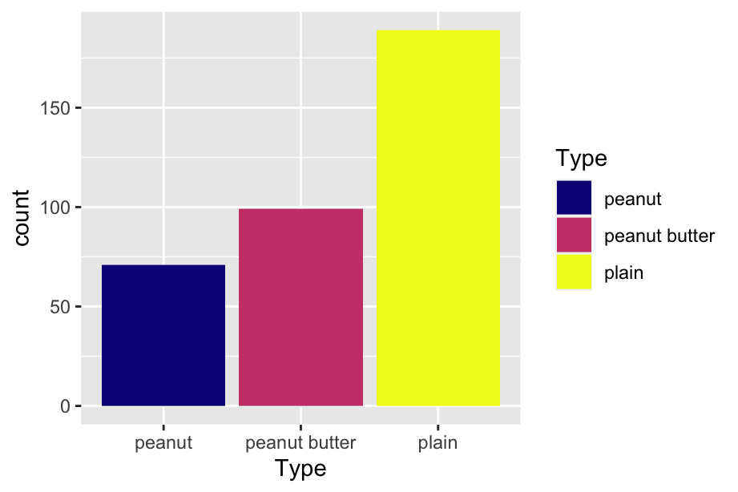

   ```r
   mm %>% ggplot(aes(x = Type, fill = Type)) +
     geom_bar() +
     scale_fill_viridis(discrete = TRUE, option = 'plasma')
   ```

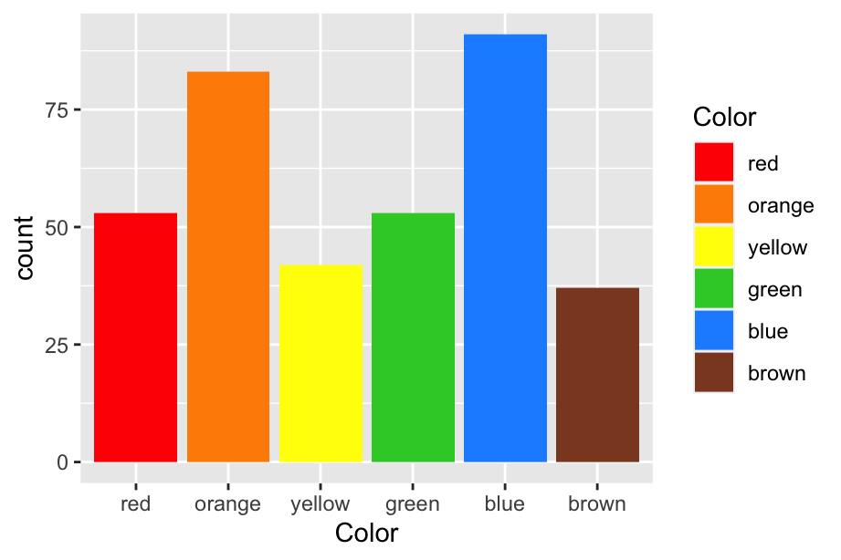

   ```r
   mmcolors = c('red','darkorange','yellow','limegreen','dodgerblue','sienna4')
   mm %>% ggplot(aes(x = Color, fill = Color)) +
     geom_bar() +
     scale_fill_manual(values = mmcolors)
   ```

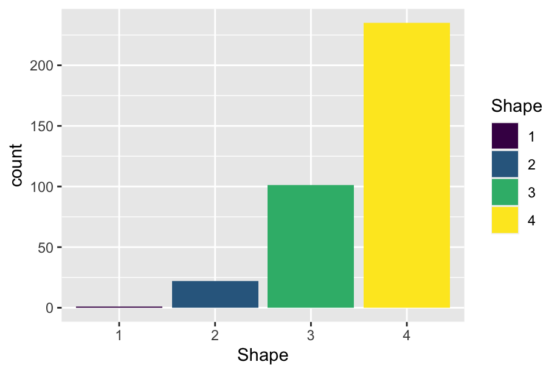

   ```r
   mm %>% ggplot(aes(x = Shape, fill = Shape)) +
     geom_bar() +
     scale_fill_viridis(discrete = TRUE)
   ```

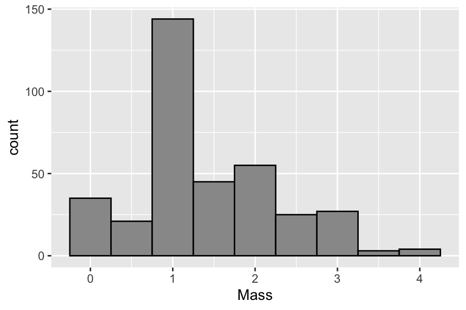

   ```r
   mm %>% ggplot(aes(x = Mass)) +
     geom_histogram(binwidth = 0.5, fill = 'grey60', color = 'black')
   ```

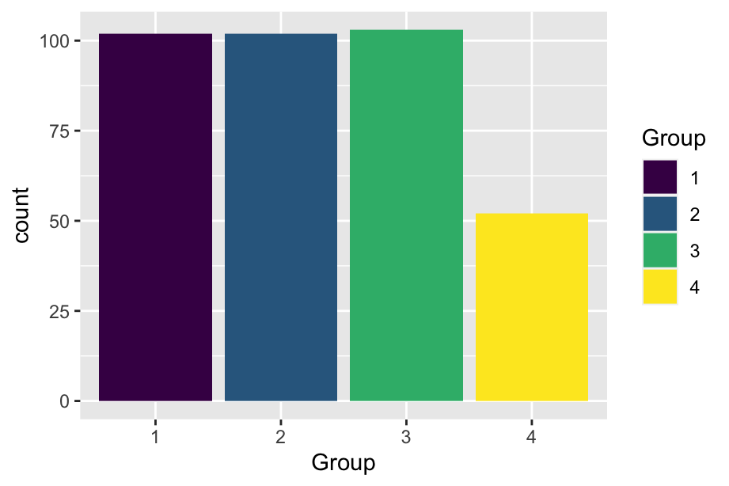

   ```r
   mm %>% ggplot(aes(x = Group, fill = Group)) +
     geom_bar() +
     scale_fill_viridis(discrete = TRUE)
   ```

3. (10 points) Obtain a density plot of mass grouped by type. Include appropriate labels. Write a sentence summarizing the relationship between mass and type.

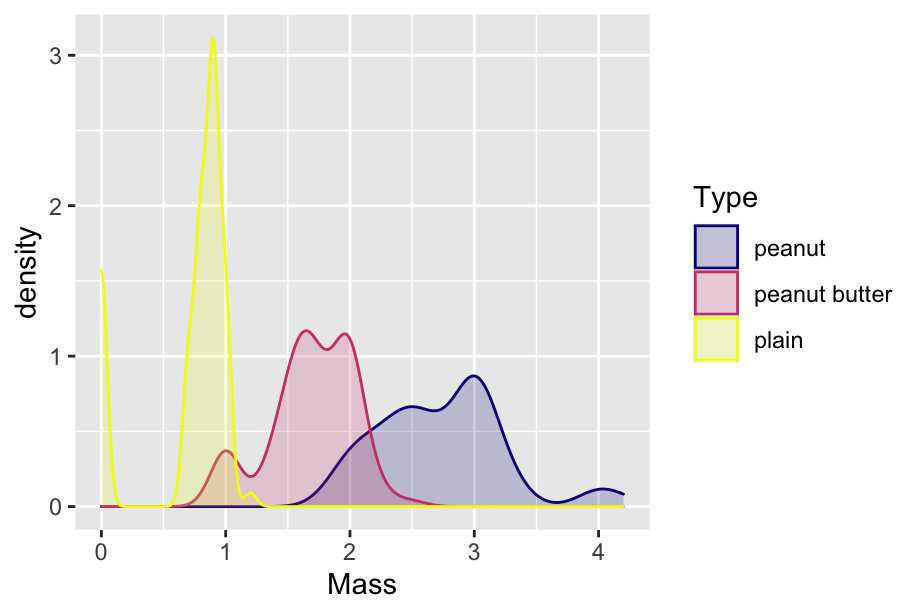

   ```r
   mm %>% ggplot(aes(x = Mass, fill = Type, color = Type)) +
       geom_density(alpha = 0.2) +
       scale_color_viridis(discrete = TRUE, option = 'plasma') +
       scale_fill_viridis(discrete = TRUE, option = 'plasma')
   ```

   Group 2 appears to have reported some of their plain M&Ms as having no mass and therefore no energy, so I guess that’s possible if their bag of plain M&Ms happened to be made of light. Otherwise, plain M&Ms were generally the lightest type, then peanut butter, then peanut, with some overlap.
4. (10 points) Obtain a stacked percentage bar chart of the colors grouped by type. Include appropriate labels. Note that your can choose the fill colors with the command `scale_fill_manual` so that the colors in the bar chart match the color of the candy. Write a sentence stating for each color the type that has the largest proportion of that color.

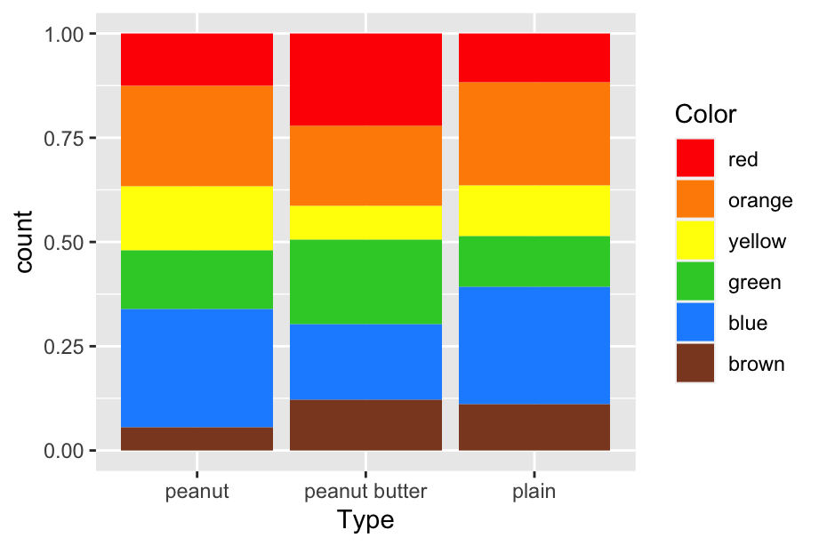

   ```r
   mmcolors = c('red','darkorange','yellow','limegreen','dodgerblue','sienna4')
   mm %>% ggplot(aes(x = Type, fill = Color)) +
       geom_bar(position = 'fill') +
       scale_fill_manual(values = mmcolors)
   ```

   Red is most prevalent among peanut butter M&Ms, orange among plain, yellow among peanut, green among peanut butter, blue among peanut, and brown among peanut butter. For orange and blue, I had to get counts by color/type and by type, then find the percentages in order to determine prevalence. For example, 28.16% of the peanut M&Ms are blue while 28.04% of the plain M&Ms are blue.
5. (10 points) Obtain a violin graph of mass grouped by the student group and faceted by the type. Write one or more sentences describing anything unusual displayed by the graph.

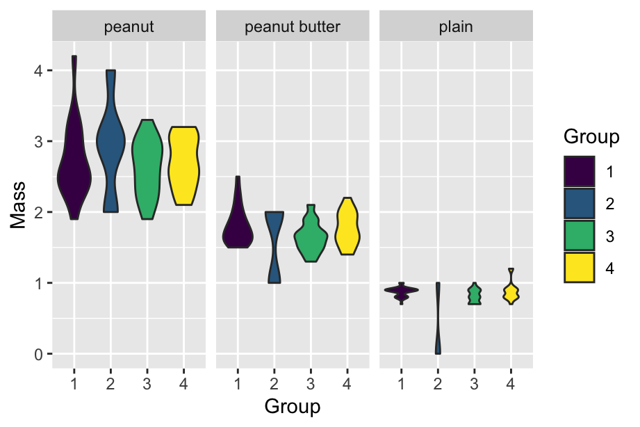

   ```r
   mm %>% ggplot(aes(x = Group, y = Mass, fill = Group)) +
       geom_violin() +
       scale_fill_viridis(discrete = TRUE) +
       facet_wrap(~ Type)
   ```